# Solutions (or Methods of Completing) to Challenges

Allison Theobold & Elijah Meyer

February 19, 2020

# Challenge 1

> Modify the previous code chunk to assign one of these aesthetics to the `geom_point` aspect of your plot. What happened?

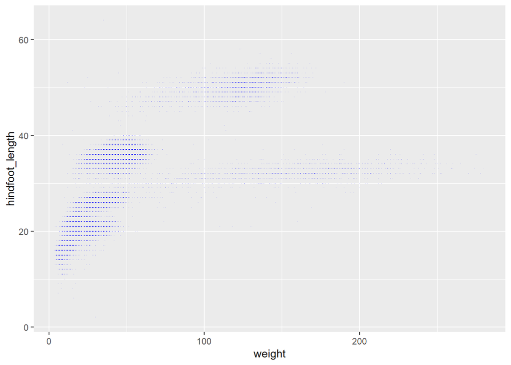

```r
ggplot(data = surveys,
       mapping = aes(x = weight, y = hindfoot_length)) +
    geom_point(alpha = 0.1, color = "blue",
               shape = ".")
```

```r
## This makes really tiny points!
```

# Challenge 2

> Part 1: Inspect the `geom_point` help file to see what other aesthetics are available. Map a new variable from the dataset to another aesthetic in your plot. What happened? Does the aesthetic change if you use a continuous variable versus a categorical/discrete variable?

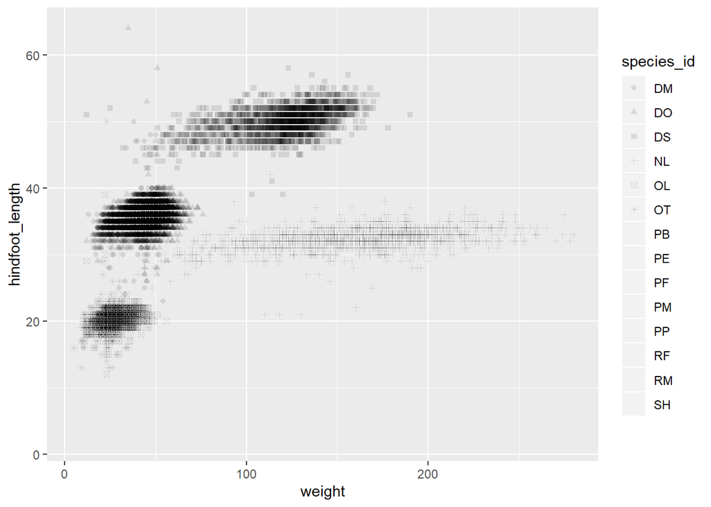

```r
surveys %>%
  ggplot(mapping = aes(x = weight, y = hindfoot_length)) +
  geom_point(aes(shape = species_id), alpha = 0.1)
```

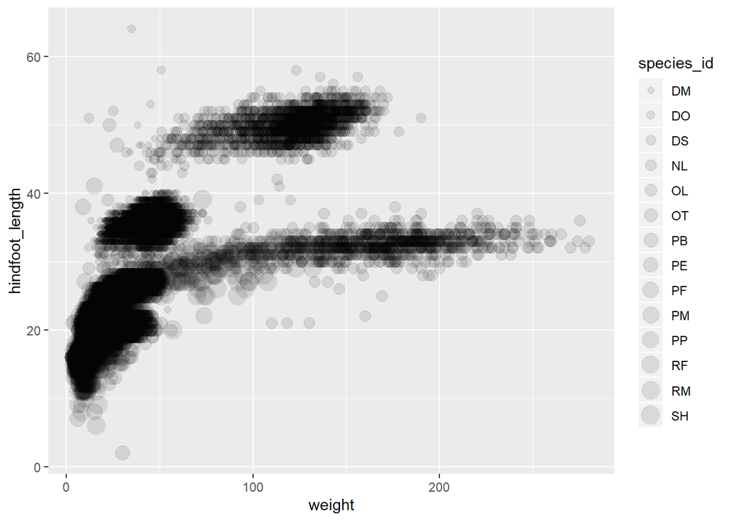

```r
## Shape is a bad choice for a categorical variable with lots of values!
## You get an error saying that it can only do up to 6 different shapes.

surveys %>%
  ggplot(mapping = aes(x = weight, y = hindfoot_length)) +
  geom_point(aes(size = species_id), alpha = 0.1)
```

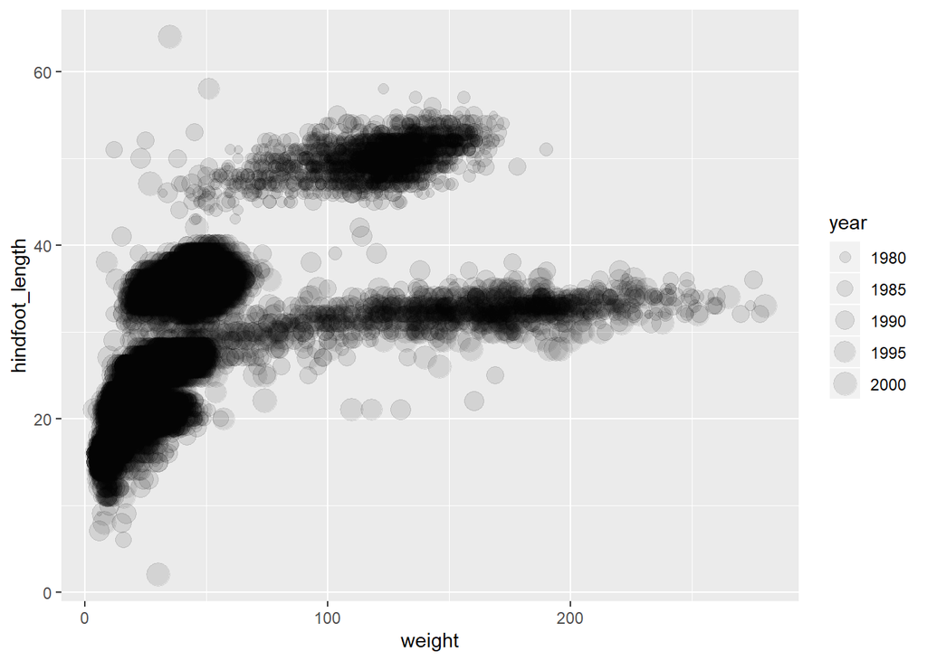

```r
## Size is a bad choice for discrete data (categorical variables)

# surveys %>%
#   ggplot(mapping = aes(x = weight, y = hindfoot_length)) +
#   geom_point(aes(shape = year), alpha = 0.1)
## This code will give you an error, you cannot use a continuous variable for shape

surveys %>%
  ggplot(mapping = aes(x = weight, y = hindfoot_length)) +
  geom_point(aes(size = year), alpha = 0.1)
```

```r
## This looks much better than using a discrete variable with size!

## The BEST possible options to map variables to are:
## color, shape, size, or group

## Stroke or alpha are not great, since they are hard to see
```

> Part 2: Use what you just learned to create a scatter plot of `weight` over `plot_id` with data from different plot types being showed in different colors.

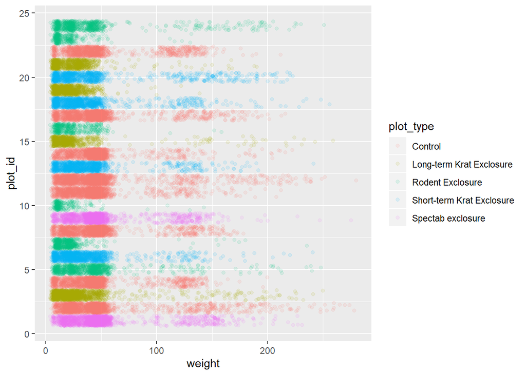

```r
surveys %>%
  ggplot(mapping = aes(x = weight, y = plot_id)) +
  geom_jitter(aes(color = plot_type), alpha = 0.1)
```

> Is this a good way to show this type of data?

No, because it looks like plot_id is a categorical variable and weight is continuous. A more “traditional” method for displaying this type of relationship is a boxplot or (the better choice) a violin plot.

# Challenge 3

> Part 1: Replace the box plot with a violin plot. For help see `geom_violin()`.

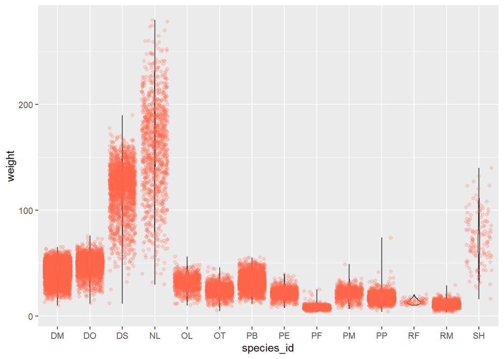

```r
surveys %>%
  ggplot(mapping = aes(x = species_id, y = weight)) +
    geom_violin() +
    geom_jitter(alpha = 0.2, color = "tomato")
```

> Part 2: So far, we’ve looked at the distribution of weight within species. Let’s try making a new plot to explore the distribution of another variable within each species.

> Create a boxplot for `hindfoot_length`. Overlay the boxplot layer on a jitter layer to show actual measurements.

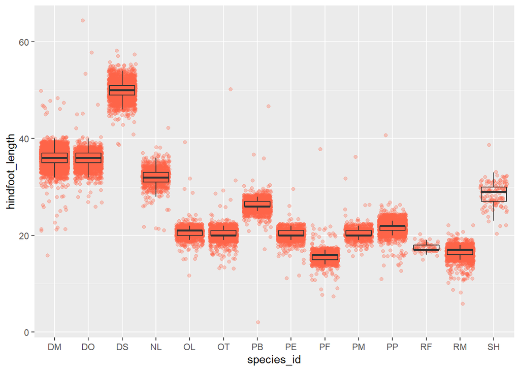

```r
surveys %>%
  ggplot(mapping = aes(x = species_id, y = hindfoot_length)) +
    geom_jitter(alpha = 0.3, color = "tomato") +
    geom_boxplot(alpha = 0)
```

```r
## Put boxplot second to have it in the front and the points in the back!
```

> Now, add color to the data points on your boxplot according to the plot from which the sample was taken (`plot_id`).

> *Hint:* Check the class for `plot_id`. If `plot_id` was a character instead, how would the graph be different?

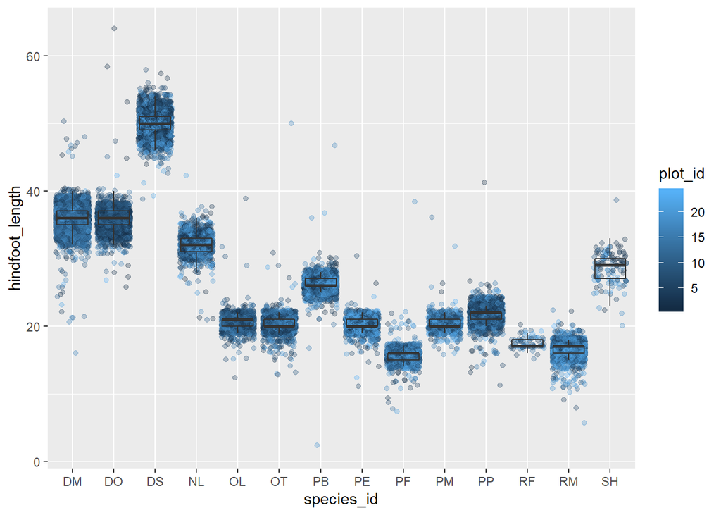

```r
surveys %>%
  ggplot(mapping = aes(x = species_id, y = hindfoot_length)) +
  geom_jitter(alpha = 0.3, mapping = aes(color = plot_id)) +
  geom_boxplot(alpha = 0)
```

```r
## Checking the data type for plot_id
class(surveys$plot_id)
```

```
## [1] "numeric"
```

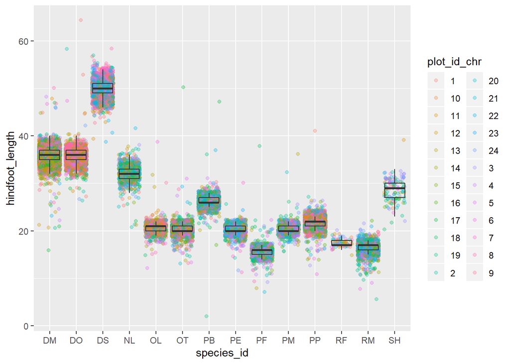

```r
## Creating a new variable named plot_id_chr
## which is the character version of plot_id
surveys <- surveys %>%
  mutate(plot_id_chr = as.character(plot_id))

## Using new character plot_id to make a boxplot
surveys %>%
  ggplot(mapping = aes(x = species_id, y = hindfoot_length)) +
  geom_jitter(alpha = 0.3, mapping = aes(color = plot_id_chr)) +
  geom_boxplot(alpha = 0)
```

# Challenge 4

> Use the `bins` argument to play around with the number of bins in your histogram. Compare your chosen number of bins with your neighbors!

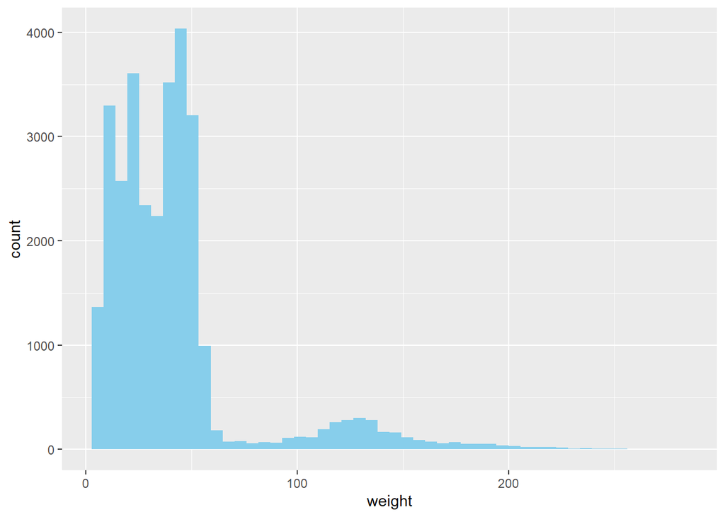

```r
surveys %>%
  ggplot(aes(x = weight)) +
  geom_histogram(fill = "sky blue" , bins = 50)
```

# Challenge 5

We need to set group = 1 because otherwise, it takes the proportion of the group versus the group total, which will always be 100%. This is not what we want!

Instead, we want the proportion of the group relative to the total, so we need to specify that it needs to consider all of these species to be part of one group.

# Challenge 6

> Change the above code so that each bar is filled with a different color.

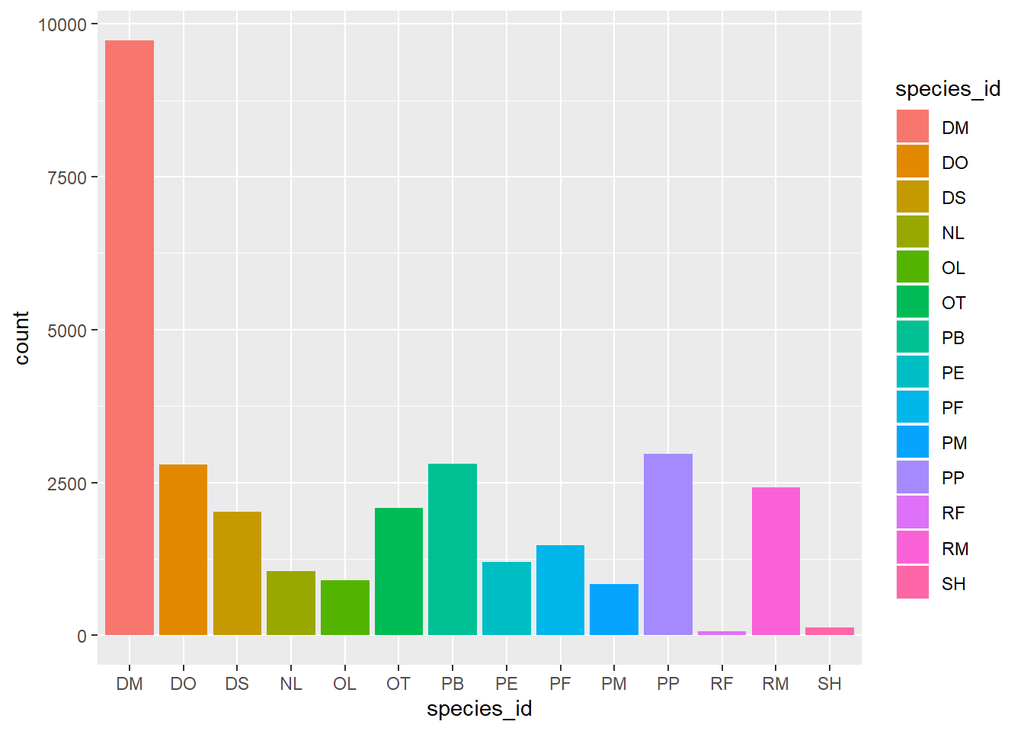

```r
surveys %>%
  ggplot(mapping = aes(x = species_id, fill = species_id)) +
  geom_bar()
```